# spatialGE: Basic tutorial for visualization and spatial heterogeneity analysis

The package `spatialGE` provides a set of tools for the visualization of gene expression from spatially-resolved arrays, such as those generated by the 10X Visium platform.

## Installation

The `spatialGE` repository is available at GitHub and can be installed via `devtools`. To install `devtools` in case is not installed in your R console, please run the following code:

```r
if("devtools" %in% rownames(installed.packages()) == FALSE) {
  install.packages("devtools")
}
```

After making sure `devtools` is installed, proceed to install `spatialGE`:

```r
#devtools::install_github("fridleylab/spatialGEdev")
```

To use `spatialGE`, load the package using the command:

```r
# library(spatialGEdev)

fx_dir <- list.files(path="~/OneDrive - Moffitt Cancer Center/SPATIAL_TRANSCRIPTOMICS/code/spatialGEdev/R",
           full.names=T)
fx_dir <- grep(".R$", fx_dir, value=T)
sapply(fx_dir, FUN=source)
```

[output not shown]

[output cut: 45 more lines]

[output not shown]

## Spatially-resolved expression of melanoma stage III tumor biopsies

To show the utility of `spatialGE`, we use the Spatial Transcriptomics data set generated by Thrane et al. (2018) that included lymph node biopsies from four stage IIIc melanoma patients, with two arrays per biopsy (DOI: 10.1158/0008-5472.CAN-18-0747). The spatial slides used in this melanoma comprised 1,007 ‘spots’ with 200μM of distance between their centers. The spots had a diameter of 100μM, covering 5-40 cells according to the authors.

In the data provided as example for `spatialGE`, we have removed probe names and duplicate gene names (resulting from different probes). The user can find the original raw data at the authors website (https://www.spatialresearch.org/resources-published-datasets/doi-10-1158-0008-5472-can-18-0747/).

## Creating an STList (Spatial Transcriptomics List)

Raw and processed data are stored in an STList (an R S4 class object). The STList can be created with the function `STList()`, which takes minimally two files: 1. A text file containing file paths of gene raw count matrices, one per line. The gene count matrices must be tab-separated, with gene names in the first column, and spots in subsequent columns. Matrices of different for each tissue slice are allowed, but duplicated gene names are not. 2. A text file containing file paths of x,y coordinates for each spot, one per line. The order of the coordinate file paths must match that of the raw count matrices.

Optionally, the user can provide a table with clinical/phenotype data associated with each spatial array. This table is a comma-separated file with sample ID in the first column, and relevant variables in subsequent columns. The order of the rows in the clinical file must match that of the file paths.

The example files in this tutorial can be downloaded from the GitHub repository (https://github.com/FridleyLab/spatialGEdev/tree/main/inst/extdata). They are also stored in you local `spatialGE` installation:

```r
# count_files <- system.file("extdata", "fpaths_count_files.txt", package = "spatialGEdev")
# coord_files <- system.file("extdata", "fpaths_mapping_files.txt", package = "spatialGEdev")
# clin_file <- system.file("extdata", "thrane_clinical.csv", package = "spatialGEdev")

count_files <- "~/OneDrive - Moffitt Cancer Center/SPATIAL_TRANSCRIPTOMICS/code/spatialGEdev/inst/extdata/short_test_version_3subjs/fpaths_count_files.txt"
coord_files <- "~/OneDrive - Moffitt Cancer Center/SPATIAL_TRANSCRIPTOMICS/code/spatialGEdev/inst/extdata/short_test_version_3subjs/fpaths_mapping_files.txt"
clin_file <- "~/OneDrive - Moffitt Cancer Center/SPATIAL_TRANSCRIPTOMICS/code/spatialGEdev/inst/extdata/short_test_version_3subjs/thrane_clinical.csv"
```

We can load the files into an STList object like so:

```r
melanoma <- STList(countfiles = count_files,
                   coordfiles = coord_files,
                   clinical = clin_file
)
```

```
#> Creating STList...
```

The `melanoma` object is an STList, and contains the count data, spot coordinates, and clinical data.

```r
melanoma
```

```
#> Spatial Transcriptomics List (STList)
#> 3 spatial arrays.
#> 6 variables in clinical data.
```

## Exploring variation between spatial arrays

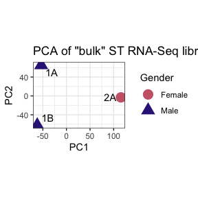

```r
bulk_pca(melanoma, clinvar='Gender')
```

## Data normalization of spatially-resolved transcriptomic data

Many normalization methods are available for both bulk and single-cell RNA-Seq data. In `spatialGE`, we apply limma-voom normalization to RNA-Seq libraries from each of the spots in order to obtain a gaussian-shape normal distribution required by most methods in this package. Many of the methods implemented in `spatialGE` have been borrowed from the field of geostatistics, which often require this kind of data normalization.

Normalization is achieved by applying the function `voom_norm()` to the `melanoma` object.

```r
melanoma <- voom_norm(melanoma)
```

```
#> Normalizing spatial array #1...
#> Normalizing spatial array #2...
#> Normalizing spatial array #3...
```

## Visualization of gene expression from spatially-resolved transcriptomics data

After normalization, expression of specific genes can be visualized using ‘quilt’ plots. The function `plot_gene_quilt()` re-creates the shape of the spatial array and shows the scaled normalized expression of a gene. We have adopted the color palettes from the package `khroma`. The color palette can be passed using the argument `color_pal`. The default behavior of the function produces plots for all spatial arrays in the STList, but we can define who should be plotted using the argument `plot_who`.

Let’s produce a quilt plot for the gene CAPG and SOX10, two genes known to be expressed in melanoma.

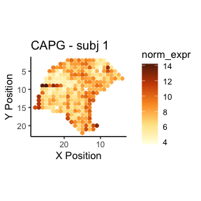

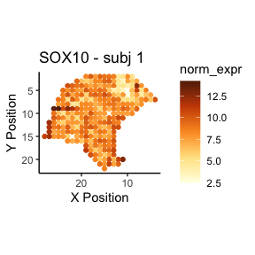

```r
plot_gene_quilt(melanoma, genes=c('CAPG', 'SOX10'), color_pal="YlOrBr", plot_who=1)
```

We can see that gene expression patterns of both genes are different, with a more dispersed pattern in CAPG, compared to SOX10. The large area of lower CAPG expression corresponds to the melanoma pocket detected by Thrane et al. (see Figure 3 of their study).

### Spatial interpolation (‘kriging’) of gene expression

We can predict a smooth surface of the gene expression in a spatial array. In `spatialGE`, this prediction is achieved by a type of spatial interpolation widely used on geographic data. The method named ‘kriging’ allows for the estimation of the normalized gene expression value of the unsampled areas between spots, or spots for which a RNA-Seq library failed to provide data. Estimating a transcriptomic surface via kriging assumes that gene expression of two given points is correlated with the physical distance between them.

The function `gene_krige()` performs kriging of gene expression via the `geoR` package:

```r
melanoma <- gene_krige(melanoma, genes=c('CAPG', 'SOX10'), who=c(1, 3))
```

```
#>
#> Performing spatial interpolation ('kriging') of gene CAPG for subject 1...
#> Performing spatial interpolation ('kriging') of gene SOX10 for subject 1...
#> Performing spatial interpolation ('kriging') of gene CAPG for subject 3...
#> Performing spatial interpolation ('kriging') of gene SOX10 for subject 3...
```

The surface can be visualized using the `plot_gene_krige()` function:

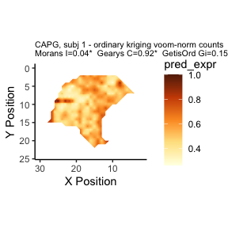

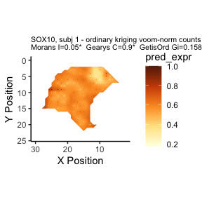

```r
plot_gene_krige(melanoma, genes=c('CAPG', 'SOX10'), plot_who=1)
```

By looking at the transcriptomic surfaces of the tho genes, it is easier to detect pockets of higher (or lower) expression within the tissue. It is now more evident that expression of CAPG is lower on the left (melanoma) portion of the tumor slice, compared to the rest of the slice.

In the transcriptomic surface plots, `spatialGE` outputs three spatial heterogeneity statistics: Moran’s I, Geary’s C, and Getis-Ord Gi.

Heterogeneity statitstics in `spatialGE`

| Low | Statistic | High |
| --- | --- | --- |
| Dispersion | Moran’s I | Clustering |
| Clustering | Geary’s C | Dispersion |
| “Cold spots” | Getis-Ord Gi | “Hot spots” |

In this case, the two genes showed almost the same values for all three statistics. A slighlly lower Moran’s I for CAPG is a result of higher dispersion of spots with high expression values through the slice surface. Both Moran’s I and Geary’s C showed statistical significance (*p*<0.05) after a permutation test (performed with `spdep`).

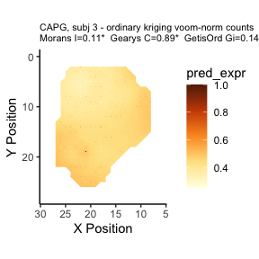

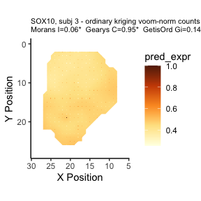

```r
plot_gene_krige(melanoma, genes=c('CAPG', 'SOX10'), plot_who=3)
```